# Tema 07 - Anexo

Material de consulta: se mira cuando hace falta

Pedro Albarrán

Dpto. de Fundamentos del Análisis Económico. Universidad de Alicante

## Esto es material de consulta

- Lo que hay aquí amplía el Tema 07: las dos capas de elegir y evaluar, las métricas, la comparación con `cv.glmnet()` del Tema 06, la correspondencia con scikit-learn en Python, los errores más frecuentes y otros pasos de receta
- Se consulta cuando hace falta en un trabajo; en clase no se ve

# Elegir y evaluar

## Partir: entrenamiento, prueba y validación cruzada

- Elegir $\lambda$ y evaluar el modelo elegido son **dos usos** de los datos, y piden dos capas:

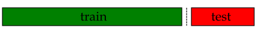

- Fuera, **una** partición (`initial_split()`): la prueba se usa una vez

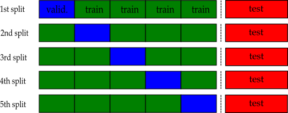

- Dentro del entrenamiento, los bloques (`vfold_cv()`) eligen $\lambda$
- El error de prueba depende de qué clientes cayeron en ella. La capa de fuera también puede ser una validación cruzada en lugar de `initial_split()`: es la validación cruzada **anidada**

## Si el mejor valor cae en el borde de la rejilla

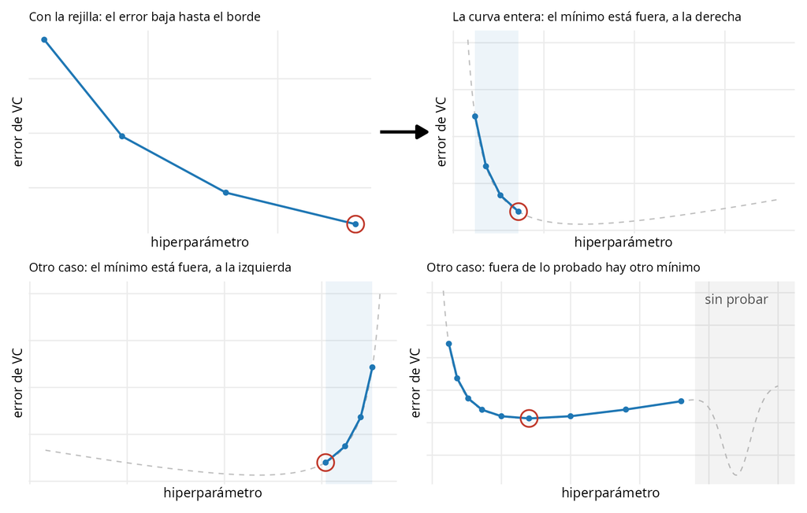

- Con la rejilla, el error baja hasta el último valor y el mejor cae en el **borde**
  - en la curva entera, el mínimo está fuera: se **amplía el rango** por ese lado hasta que el mejor quede dentro
- Otros casos: el mínimo fuera por el otro extremo, y otro mínimo en una zona sin probar
- La rejilla también se puede escribir a mano, con los valores que se quieran: `grid = tibble(penalty = c(0.01, 0.1, 1, 10, 100))` en `tune_grid()`

## Zoom: una rejilla más fina alrededor del mejor

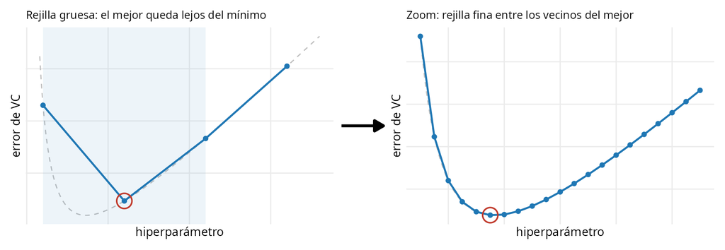

- Con una rejilla **gruesa**, el mínimo puede caer entre dos valores probados: el mejor de la rejilla queda lejos de él
- Se hace **zoom**: una rejilla más fina entre los dos vecinos del mejor
  - en escala logarítmica, `penalty(range = ...)` con los exponentes de esos vecinos y más `levels`

## Tres errores del mismo modelo

```r
augment(extract_workflow(final), new_data = training(part)) |> rmse(ventas, .pred)
```

| Error | RMSE | De dónde sale | Para qué sirve |
| --- | --- | --- | --- |
| Entrenamiento | 319 | el código de arriba: el modelo final predice sus propios clientes | nada: es optimista |
| Validación cruzada | 363 | `show_best()`, en el Tema 07 | **elegir** $\lambda$ |
| Prueba | 340 | `collect_metrics(final)`, en «Finalizar y evaluar» | **informar** del error |

- El 363 se mide en clientes de evaluación, que no se usaron para estimar. Pero $\lambda$ se eligió por dar el menor de 71 errores medios, y el menor de 71 cifras con ruido tiende a quedar por debajo del error real: **sesgo de optimización**
- La prueba no intervino en ninguna decisión, y por eso su error es el que se informa. Aquí sale incluso más bajo (340): con 81 clientes, el azar de quiénes caen en la prueba pesa más que ese sesgo («Partir: entrenamiento, prueba y validación cruzada»)

# Del Tema 06 a `tidymodels`

## Los mismos pasos con `cv.glmnet()`

| Paso | Tema 06, con `glmnet` | Tema 07, con `tidymodels` |
| --- | --- | --- |
| Partir | `sample()` (Tema 05) | `initial_split()` |
| Bloques | `nfolds` dentro de `cv.glmnet()` | `vfold_cv()` |
| Preprocesado, modelo y flujo | `model.matrix()` y `glmnet(x, y, alpha)` | fórmula o `recipe()`, `linear_reg()` y `workflow()` |
| Afinar | `cv.glmnet()`, `plot()`, `lambda.min`, `lambda.1se` | `tune_grid()`, `autoplot()`, `select_best()`, `select_by_one_std_err()` |
| Finalizar y evaluar | `coef(cv, s = )`, `predict()` | `finalize_workflow()`, `last_fit()`, `collect_metrics()` |
| Métricas | a mano | `rmse()`, `mae()`, `roc_auc()`, `sens()`… |

- En el Tema 06, `cv.glmnet()` hizo los bloques sobre los 404 clientes y midió el error del $\lambda$ elegido en esos mismos bloques: es optimista, porque $\lambda^*$ se eligió por dar el mínimo (**sesgo de optimización**), y no quedaba prueba para evaluar
- Lo que `cv.glmnet()` daba en `cvm` y `cvsd` es `mean` y `std_err` de `collect_metrics()`; `plot(cv)` es `autoplot()`, con el eje en $-\log(\lambda)$, así que la U sale al revés
- Con `cv.glmnet()` sobre los 404 clientes, $\lambda$ salía 21,3 y 37,2 (mínimo y un error estándar); en el Tema 07, con solo el entrenamiento, 20,0 y 31,6

# `tidymodels` y scikit-learn

## La misma gramática en Python

- En Python, lo equivalente a `tidymodels` es scikit-learn. La lógica es idéntica y cambian los nombres:

| Paso | `tidymodels` (R) | scikit-learn (Python) |
| --- | --- | --- |
| Partir | `initial_split(prop = 0.8)` | `train_test_split(test_size = 0.2)` |
| Bloques | `vfold_cv(v = 10)`, `strata =` | `KFold(10)`, `StratifiedKFold(10)` |
| Preprocesado que aprende | `recipe()`, `step_normalize()`, `prep()`, `bake()` | `StandardScaler()`, `.fit()`, `.transform()` |
| Modelo | `linear_reg(penalty, mixture = 1)` con `glmnet` | `Lasso(alpha)`; `LogisticRegression(penalty = "l1", C)` |
| Flujo | `workflow(receta, modelo)` | `Pipeline([("sc", StandardScaler()), ("m", Lasso())])` |
| Rejilla y afinado | `grid_regular()`, `tune_grid(grid, metrics)` | `GridSearchCV(param_grid, cv, scoring)` |
| Mejor y reajuste | `select_best()`, `finalize_workflow()`, `last_fit()` | `best_params_`, `refit = True`, `.score(X_test, y_test)` |
| Métricas | `rmse()`, `roc_auc()`, `sens()` | `mean_squared_error`, `roc_auc_score`, `recall_score` |
| Camino de $\lambda$ barato | `cv.glmnet()` (Tema 06) | `LassoCV`, `LogisticRegressionCV` |

# Métricas

## Métricas: `metric_set()`

- Todas las métricas de `yardstick` se pasan a `metric_set()`, a `tune_grid()` y a `last_fit()` igual: [lista completa](https://yardstick.tidymodels.org/reference/index.html)
- **Regresión**, con la respuesta y `.pred`:
  - `rmse()`, `mae()`: errores en las unidades de la respuesta
  - `rsq()`: $R^2$; `mape()`: error porcentual medio
- **Clasificación con la clase predicha** (`.pred_class`, umbral 0,5):
  - `accuracy()`: exactitud; `sens()` y `spec()`: sensibilidad y especificidad; `precision()`; `f_meas()`
  - `conf_mat()`: la matriz de confusión
- **Clasificación con la probabilidad** (`.pred_Sí`):
  - `roc_auc()`: AUC; `mn_log_loss()`: menos la log-verosimilitud media; `brier_class()`: error cuadrático de la probabilidad

# Errores frecuentes y otros pasos de receta

## Errores frecuentes

| Cuidado con | Qué pasa | Cómo evitarlo |
| --- | --- | --- |
| El orden de los niveles de un factor, p.e. `churn` con «No» y «Sí» en orden alfabético | Las métricas toman el primer nivel como el suceso: el AUC sale 0,25 en vez de 0,75 | Fijar el orden antes de partir: `factor(churn, levels = c("Sí", "No"))` |
| Transformar la respuesta con un paso de la receta, p.e. `step_log(ventas)` | Sin `skip`, no se puede predecir; con `skip = TRUE`, las predicciones quedan en logaritmos | Transformarla antes de partir: `mutate(lventas = log(ventas))` |
| Crear un factor dentro de la fórmula, p.e. `factor(educ)` | Falla en los bloques donde falta algún nivel | Crearlo antes de partir: `mutate(educ = factor(educ))` |
| Elegir sin decir la métrica, p.e. `select_best(ajuste)` | Avisa y elige con la primera métrica | `select_best(ajuste, metric = "rmse")` |
| Evaluar sin decir las métricas, p.e. `last_fit()` sin `metrics` | Calcula las de por defecto, que pueden no ser las usadas al afinar | `last_fit(..., metrics = metric_set(roc_auc, accuracy))` |

## Otros pasos de receta

- **Valores ausentes** (Tema 04): dos salidas, cada una con sus problemas
  - quitar las filas, con `drop_na()` antes de partir
  - imputar, con un paso de la receta: el valor de relleno se aprende en el entrenamiento
  - hay muchas formas de imputar: media (`step_impute_mean()`), mediana, moda, regresión (`step_impute_linear()`), observaciones parecidas (`step_impute_knn()`)…
- `step_dummy()` quita por defecto una categoría, la de referencia, como en la regresión
  - otros modelos usan una columna por categoría: `step_dummy(one_hot = TRUE)`
- `step_normalize()` deja cada variable con media 0 y desviación típica 1, las del entrenamiento
  - algunos motores, como `glmnet`, ya estandarizan por dentro
- `step_other()` junta en «other» las categorías con pocos casos
- `step_cut()` parte una variable numérica en tramos (p.e. `step_cut(edad, breaks = c(30, 50))`)
- `step_zv()`, `step_nzv()` y `step_corr()` quitan variables sin variación, casi constantes o muy correlacionadas
  - algunas IA los recomiendan siempre, pero muchos de estos problemas se detectan en el análisis exploratorio
  - otros aparecen con el preprocesado, y ahí sí tienen sentido: en la práctica 1, los productos de dos categorías de un mismo factor valen siempre 0
- Todos los pasos: https://recipes.tidymodels.org/reference/